# Applications of variable-effort survey design

Analysing Ecological Data with Detection Error

Author

Péter Sólymos

Published

April 23, 2026

```r
library(detect)
```

```
detect 0.5-1     2026-01-04
```

```r
library(bSims)
```

```
mefa4 0.3-12     2025-07-12
```

```
deldir 2.0-4      Nickname: "Idol Comparison"
```

```
     The syntax of deldir() has changed since version
     0.0-10.  Read the help!!!.
```

```
bSims 0.3-3      2025-07-12      chwee-chwee-chwee
```

```r
set.seed(123)
```

# Introduction

This session is based on the paper:

Lele, S. R., Sólymos, P. 2025. Single bin QPAD (SQPAD) approach for robust analysis of point count data with detection error. Ornithological Applications, 128: 1–14. DOI 10.1093/ornithapp/duaf078 [Preprint and reproducible code](https://github.com/psolymos/sqpad-paper)

- Distance sampling requires correct estimation of the distances. Does not take into account the survey duration.
- Removal sampling requires tracking individuals and does not take into account the effect of the distance.
- QPAD accounts for both distance and survey duration but uses an independence assumption. It inherits the problems of distance and removal sampling.
- N-mixture type approaches require multiple, independent visits and close population assumption. Logistically and financially difficult and biologically not justifiable.

We propose a method that addresses many of these issues without making any additional assumptions, the Single Bin QPAD (SQPAD), that:

- Does not need individual distance estimation. It only requires that one can determine if an individual is within a specified spatial buffer.
- Does not require tracking individuals.
- Does not need the independence assumption of QPAD.
- Does not need replicate surveys or multiple simultaneous observers.
- The trick behind the SQPAD is the variable effort survey design.

## Notation

Let $s=1,2,⋯,S$ where $S$ is the total number of locations that are surveyed.

- $y_s$ is the occupancy status or abundance at the $s$-th survey location
- $X_s$ is a vector of habitat covariates that affect abundance and density at the time and location of the $s$-th survey
- $Z_s$ is a vector of habitat covariates that affect detection at the time and location of the $s$-th survey
- $t_s$ is the survey duration at the $s$-th survey
- $r_s$ is the radius of the circular buffer around the $s$-th survey
- Survey area around the $s$-th survey location is $A_s=πr_s^2$.
- Let $R_{max}$ be the maximum radius one would survey at any survey location
- Let $R_{min}>0$ denote the minimum radius surveyed at any survey location.
- Let $T_{max}$ denote the maximum amount of time spent at any survey location.
- Let $T_{min}>0$ denote the minimum amount of time one spends at any survey location.

## Variable Effort Survey Design

- Step 1: Choose a location from all the potential survey locations. This could be based on simple random sampling, stratified simple random sampling or any other sampling design one wishes to use.
- Step 2: Choose a number from $(T_{min},2T_{min},⋯,T_{max}/T_{min})$ randomly where $T_{min}$ is the minimum amount of time spent at a survey location. This is the amount of time one would spend at the chosen location.
- Step 3: Choose a number from $(R_{min},2R_{min},⋯,R_{max}/R_{min})$ randomly where $R_{min}$ is the smallest radius for the buffer at a survey location. This is the survey radius at the chosen location.
- Step 4: Note the number of individuals or occupancy status observed at that survey location within the survey radius in Step 3 and during the survey duration in Step 2.
- Step 5: Repeat Steps 1-4, until a requisite number of locations are surveyed.

We want to emphasize that the survey radius and survey duration are different for each survey location. This is in contrast to the usual practice of having these to be the same for all survey locations. We call this a variable effort survey design.

Data collected under the variable effort survey design are $(y_s,X_s,Z_s,t_s,r_s)$, namely, observed abundance or occupancy status, covariates for abundance, covariates for detection, survey duration, and survey radius for each survey.

We note that there could be habitat covariates that affect both detection and abundance. Such habitat covariates will be part of both $X_s$ and $Z_s$ vectors. Of course, there may be no habitat covariates and we only have $(y_s,t_s,r_s)$.

## Statistical model: Count data

Process model: $N_s |(X_s,A_s)∼Poisson(D_s A_s)$, where $D_s$ denotes the density and $N_s$ is the true abundance at the survey location. We can model $D_s$ as a log-linear function of covariates $X_s$.

Observation model: $Y_s |(N_s=n_s,Z_s,t_s,r_s)∼Binomial(n_s,p_s)$, where $p_s$ denotes the probability of detecting an individual at the $s$-th survey time and location.

## Statistical model: Occupancy data

Process model: $N_s |(X_s,A_s)∼Binomial(1,ψ_s)$, where $ψ_s$ is the probability of occupancy. We model the probability of occupancy as a function of the density,$ψ_s=1-exp(-D_s A_s)$

Observation model: $Y_s |(N_s=n_s,Z_s,t_s,r_s)∼Binomial(n_s,p_s)$, where $p_s$ denotes the probability of detecting an individual at the $s$-th survey time and location.

## Model for probability of detection: Duration only

- An individual is detected only if that individual emanates a cue (which is always perceived)
- Cues are emanated according to a Time-Homogeneous Poisson Process with rate $\delta >0$
- Individuals emanate cues independent of each other.
- Probability that an individual is detected during the survey duration $(0,T)$ is $1-exp(-\delta T)$.

## Model for probability of detection: Duration and distance effect

- Individuals are at different distances from the observer.
- Farther an individual is from the observer, smaller is the chance that a cue emanated by that individual will be detected by the observer.
- This corresponds to a thinned point process. The perceived cue rate is reduced.

To illustrate the thinning process, we’ll use bSims.

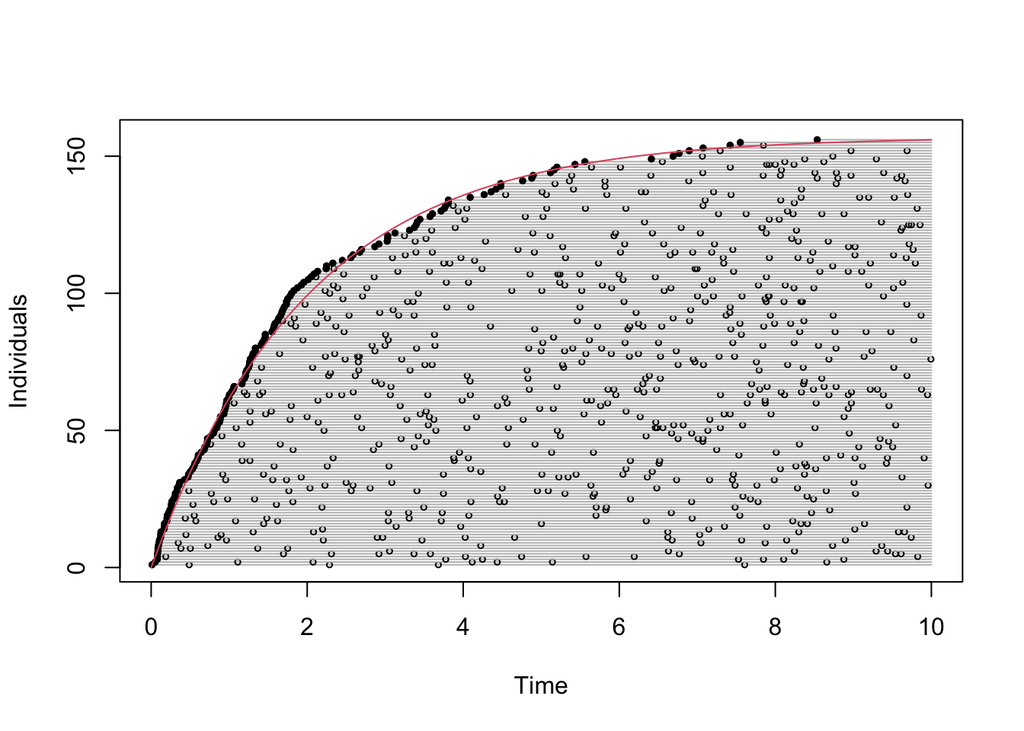

```r
b <- bsims_all(
    density = 1.5,
    vocal_rate = 0.5,
    tau = 2
)$new()

# events
v <- get_events(b)
plot(v)
curve((1 - exp(-0.5 * x)) * get_abundance(b), col = 2, add = TRUE)
```

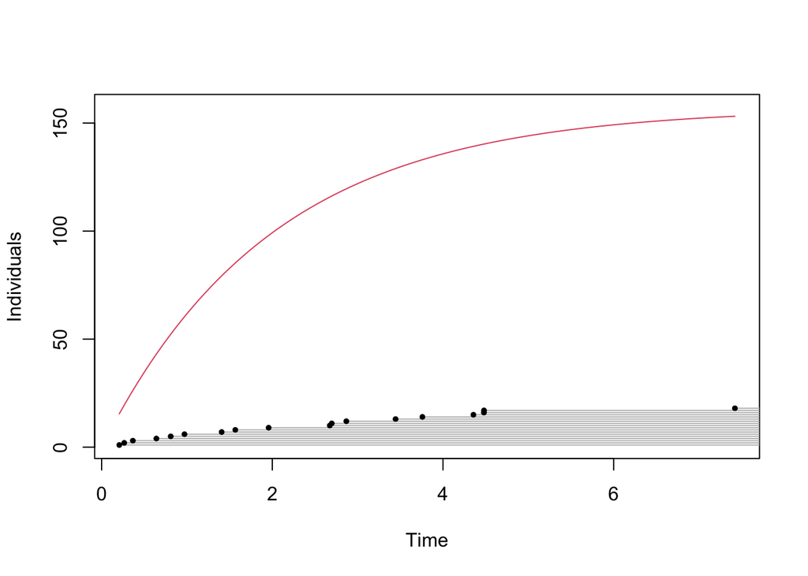

```r
# detections
q <- get_detections(b)
plot(q)
curve((1 - exp(-0.5 * x)) * get_abundance(b), col = 2, add = TRUE)
```

## Incorporating the distance effect on perception

- Similar to the visibility functions in distance sampling, let $\nu(r,\phi)$ be any function such that $\nu(0,\phi)=1$ and decreases to 0 as the distance increases.
- Perceived cue rate is $\delta\nu(r,\phi)$
- Probability that an individual at distance $r$ is detected during the survey duration $(0,T)$ is $1-exp(-\delta\nu(r,\phi) T)$.
- Exponential decay in perception will lead us to $1-exp(-\delta exp(-\phi r) T)$.
- Half Gaussian decay in perception will lead us to $1-exp(-\delta exp(-\phi r^2) T)$.
- We can include the covariate effect on the cue rate by using $\delta = \delta_0exp(Z\gamma)$

## Can we estimate the parameters using only a single visit?

It is possible to estimate the detection probability and density if:

- There are covariates that affect detection but not the density. In our case, these are survey duration and survey radius.
- Probability of detection varies continuously from 0 to 1 over the potential range of the covariates that affect detection. In our case, if the survey duration is 0, probability of detection is 0. Also, as the survey duration increases, probability of detection increases to 1.

## What information do we collect?

- We observe that that there 3 individuals (when in reality there are 5 individuals)
- Full information corresponds to $(t_1,d_1),(t_2,d_2),(t_3,d_3)$
- Distance sampling uses $d_1,d_2,d_3$
- Removal sampling uses $t_1, t_2,t_3$
- QPAD uses full information but fits the independence model
- SQPAD uses $(y_s=3,t_s=10,r_s=100)$ (Three individuals during 10 minutes and within 100 mtrs)

## ARU data analysis

- There is a relationship between sound pressure and distance.
- We can use this relationship to replace distance by sound pressure in the distance effect component of the probability of detection (no need for transformation to distance)
- We can use estimated distance to compute effective area. This is needed for computing density.
- Area is a random effect with known mean and known variance based on the calibration studies.
- This is likely to be robust because we only need to know if the distance is smaller than a specified value and not the exact distance.

## Discussion

- It seems mysterious that one can correct for detection error without auxiliary information.
- Key is variable survey duration and variable survey radius. These can be used as covariates.
- These covariates affect only the detection process (not the density)
- Key assumption: Probability of detection increases from 0 to 1 as survey duration increases from 0 to $\infty$. (Satisfies the RSPF condition)
- Misclassfication of an individual inside or outside the buffer can affect the inferences. But simulations suggest SQPAD in general, and occupancy in particular, robust against this error.
- No distraction by trying to track individuals or distances
- No replicate surveys
- More reliable counts and occupancy status because of less distraction
- Logistically and financially advantageous
- Currently available data can be analyzed using the composite likelihood

# Simulations

A full simulation example using bSims can be found at https://github.com/psolymos/sqpad-paper.

Here we’ll do statistical simulations to demonstrate how the functions work.

```r
n <- 200
x <- rnorm(n)
D <- exp(-2 + 0.5 * x)
phi <- 0.25
tau <- 1
dur <- sample(1:10, n, replace = TRUE)
dis <- sample(seq(0.5, 2, 0.25), n, replace = TRUE)
A <- dis^2 * pi
dcorr <- 2 / 3
p <- 1 - exp(-dur * phi * exp(-(dis * dcorr)^2 / tau^2))
N <- rpois(n, D * A)
Y <- rbinom(n, N, p)

df <- data.frame(x = x, y = Y)
```

Estimate effects (note: `phi` estimate here refers to the distance effect, `delta` if for the cue rate):

```r
m <- sqpad(y ~ x | 1,
    data = df,
    dis = dis, dur = dur,
    type = "full", det = "joint",
    K = NULL
)

print(m)
```

```
Call:
sqpad(formula = y ~ x | 1, data = df, dis = dis, dur = dur, type = "full",
    det = "joint", K = NULL)

Single-bin QPAD model with dependence
Full Maximum Likelihood estimates

Coefficients:
    log.D_(Intercept)                log.D_x  log.delta_(Intercept)
              -2.4858                 0.4426                 1.4247
              log.phi
              -0.4564
```

```r
summary(m)
```

```
Call:
sqpad(formula = y ~ x | 1, data = df, dis = dis, dur = dur, type = "full",
    det = "joint", K = NULL)

Single-bin QPAD model with dependence
Full Maximum Likelihood estimates

Coefficients:
                      Estimate Std. Error z value Pr(>|z|)
log.D_(Intercept)      -2.4858     0.2423 -10.261  < 2e-16 ***
log.D_x                 0.4426     0.1355   3.267  0.00109 **
log.delta_(Intercept)   1.4247     1.5963   0.892  0.37215
log.phi                -0.4564     0.1899  -2.403  0.01625 *
---
Signif. codes:  0 '***' 0.001 '**' 0.01 '*' 0.05 '.' 0.1 ' ' 1

Log-likelihood: -125.7
BIC = 272.6
```

```r
coef(m)
```

```
    log.D_(Intercept)               log.D_x log.delta_(Intercept)
           -2.4857502             0.4425576             1.4246689
              log.phi
           -0.4564443
```

```r
c(-2, 0.5, log(0.25), log(1))
```

```
[1] -2.000000  0.500000 -1.386294  0.000000
```

```r
nobs(m)
```

```
[1] 200
```

```r
vcov(m)
```

```
                      log.D_(Intercept)      log.D_x log.delta_(Intercept)
log.D_(Intercept)            0.05868629 -0.009891100           -0.24178279
log.D_x                     -0.00989110  0.018354083           -0.01408417
log.delta_(Intercept)       -0.24178279 -0.014084167            2.54831169
log.phi                      0.02137710  0.002340066           -0.29189077
                           log.phi
log.D_(Intercept)      0.021377096
log.D_x                0.002340066
log.delta_(Intercept) -0.291890768
log.phi                0.036069240
```

```r
confint(m)
```

```
                           2.5 %      97.5 %
log.D_(Intercept)     -2.9605564 -2.01094395
log.D_x                0.1770271  0.70808814
log.delta_(Intercept) -1.7041063  4.55344413
log.phi               -0.8286787 -0.08420979
```

```r
logLik(m)
```

```
'log Lik.' -125.683 (df=4)
```

```r
AIC(m)
```

```
[1] 259.366
```

```r
BIC(m)
```

```
[1] 272.5592
```

```r
fitted(m)
```

```
         1          2          3          4          5          6          7
0.08759387 0.15368881 0.17783000 0.18730650 0.04660340 0.05827071 0.04770164
         8          9         10         11         12         13         14
0.06918740 0.09531011 0.09044941 0.07516526 0.07773264 0.06919848 0.05688991
        15         16         17         18         19         20         21
0.06017903 0.05769105 0.06652215 0.04491808 0.14368504 0.19745028 0.04665352
        22         23         24         25         26         27         28
0.14513226 0.08754230 0.08425480 0.08544524 0.10193363 0.08713528 0.05688318
        29         30         31         32         33         34         35
0.08851060 0.12261376 0.07500851 0.04843043 0.04009327 0.10968232 0.08094065
        36         37         38         39         40         41         42
0.06403699 0.09200543 0.06119026 0.08028255 0.09449262 0.03377353 0.05385992
        43         44         45         46         47         48         49
0.04639096 0.04815496 0.16551747 0.14058582 0.11677717 0.07066229 0.14064335
        50         51         52         53         54         55         56
0.04850072 0.03442116 0.02180988 0.09207509 0.08461787 0.05869439 0.10338769
        57         58         59         60         61         62         63
0.08483898 0.07282836 0.14633838 0.15747479 0.13207083 0.10842198 0.05345280
        64         65         66         67         68         69         70
0.07459745 0.08164275 0.08896165 0.13655756 0.04442523 0.04569850 0.08107959
        71         72         73         74         75         76         77
0.04342536 0.13648461 0.07729200 0.02528687 0.07492326 0.09142936 0.05918584
        78         79         80         81         82         83         84
0.04755141 0.08374445 0.14311449 0.06734411 0.13609876 0.15479759 0.04758819
        85         86         87         88         89         90         91
0.12213033 0.07937770 0.09282991 0.18105133 0.12850023 0.06725491 0.04285407
        92         93         94         95         96         97         98
0.09777842 0.10516036 0.14246291 0.15674123 0.09159329 0.08967185 0.10119515
        99        100        101        102        103        104        105
0.13449036 0.08966598 0.07009328 0.05222018 0.08376718 0.08270203 0.08327850
       106        107        108        109        110        111        112
0.06993493 0.06410052 0.12543671 0.07814071 0.16596015 0.05888033 0.03681672
       113        114        115        116        117        118        119
0.07757211 0.12466035 0.07779532 0.04139946 0.06433732 0.08183690 0.14829980
       120        121        122        123        124        125        126
0.13688363 0.11922002 0.10257752 0.05808689 0.11922193 0.14276755 0.11563878
       127        128        129        130        131        132        133
0.14014719 0.09525810 0.13068277 0.15495970 0.05424353 0.16309103 0.11680471
       134        135        136        137        138        139        140
0.11376930 0.08601780 0.05456305 0.04788337 0.09519867 0.07811079 0.13339867
       141        142        143        144        145        146        147
0.08266384 0.07065281 0.16253184 0.07403779 0.06177617 0.11207954 0.16194660
       148        149        150        151        152        153        154
0.05403771 0.07378023 0.07146266 0.08448032 0.09640621 0.11501960 0.13234229
       155        156        157        158        159        160        161
0.06028579 0.08275023 0.11798602 0.06400201 0.10189598 0.18017112 0.04596438
       162        163        164        165        166        167        168
0.11472172 0.08064369 0.05345947 0.09355376 0.08146007 0.05292791 0.08399870
       169        170        171        172        173        174        175
0.10784089 0.07629349 0.18447235 0.16627451 0.05971171 0.15324398 0.14551477
       176        177        178        179        180        181        182
0.06252023 0.16672228 0.17402500 0.10985125 0.12357170 0.05318969 0.18999254
       183        184        185        186        187        188        189
0.06402508 0.07098277 0.10441827 0.08715179 0.17536452 0.06014656 0.06562893
       190        191        192        193        194        195        196
0.09355178 0.10684988 0.30436038 0.04683676 0.13648719 0.12343259 0.13564326
       197        198        199        200
0.04748335 0.09781215 0.06685923 0.03832631
```

```r
predict(m, type = "link")
```

```
        1         2         3         4         5         6         7         8
-2.435044 -1.872825 -1.726927 -1.675009 -3.066082 -2.842656 -3.042789 -2.670937
        9        10        11        12        13        14        15        16
-2.350619 -2.402965 -2.588066 -2.554480 -2.670776 -2.866637 -2.810431 -2.852653
       17        18        19        20        21        22        23        24
-2.710220 -3.102915 -1.940132 -1.622268 -3.065007 -1.930110 -2.435633 -2.473910
       25        26        27        28        29        30        31        32
-2.459880 -2.283433 -2.440293 -2.866756 -2.424633 -2.098716 -2.590154 -3.027627
       33        34        35        36        37        38        39        40
-3.216547 -2.210167 -2.514039 -2.748294 -2.385908 -2.793767 -2.522203 -2.359234
       41        42        43        44        45        46        47        48
-3.388078 -2.921369 -3.070651 -3.033331 -1.798679 -1.961937 -2.147488 -2.649843
       49        50        51        52        53        54        55        56
-1.961528 -3.026177 -3.369084 -3.825392 -2.385151 -2.469610 -2.835411 -2.269269
       57        58        59        60        61        62        63        64
-2.467000 -2.619650 -1.921834 -1.848490 -2.024417 -2.221724 -2.928956 -2.595649
       65        66        67        68        69        70        71        72
-2.505402 -2.419550 -1.991009 -3.113948 -3.085690 -2.512324 -3.136712 -1.991543
       73        74        75        76        77        78        79        80
-2.560165 -3.677470 -2.591291 -2.392189 -2.827073 -3.045944 -2.479985 -1.944110
       81        82        83        84        85        86        87        88
-2.697940 -1.994374 -1.865637 -3.045171 -2.102666 -2.533538 -2.376986 -1.708975
       89        90        91        92        93        94        95        96
-2.051825 -2.699265 -3.149955 -2.325051 -2.252269 -1.948674 -1.853159 -2.390397
       97        98        99       100       101       102       103       104
-2.411598 -2.290704 -2.006263 -2.411664 -2.657928 -2.952286 -2.479714 -2.492511
      105       106       107       108       109       110       111       112
-2.485565 -2.660190 -2.747303 -2.075954 -2.549244 -1.796008 -2.832248 -3.301803
      113       114       115       116       117       118       119       120
-2.556547 -2.082162 -2.553674 -3.184487 -2.743615 -2.503027 -1.908519 -1.988624
      121       122       123       124       125       126       127       128
-2.126785 -2.277136 -2.845815 -2.126769 -1.946537 -2.157284 -1.965062 -2.351165
      129       130       131       132       133       134       135       136
-2.034982 -1.864590 -2.914271 -1.813447 -2.147252 -2.173583 -2.453201 -2.908398
      137       138       139       140       141       142       143       144
-3.038987 -2.351789 -2.549627 -2.014413 -2.492973 -2.649977 -1.816881 -2.603180
      145       146       147       148       149       150       151       152
-2.784238 -2.188547 -1.820489 -2.918073 -2.606664 -2.638580 -2.471237 -2.339185
      153       154       155       156       157       158       159       160
-2.162653 -2.022364 -2.808659 -2.491928 -2.137189 -2.748841 -2.283803 -1.713848
      161       162       163       164       165       166       167       168
-3.079889 -2.165246 -2.517715 -2.928832 -2.369219 -2.507642 -2.938824 -2.476954
      169       170       171       172       173       174       175       176
-2.227098 -2.573168 -1.690256 -1.794115 -2.818227 -1.875724 -1.927478 -2.772265
      177       178       179       180       181       182       183       184
-1.791426 -1.748556 -2.208628 -2.090934 -2.933891 -1.660770 -2.748480 -2.645318
      185       186       187       188       189       190       191       192
-2.259351 -2.440104 -1.740888 -2.810971 -2.723739 -2.369240 -2.236330 -1.189543
      193       194       195       196       197       198       199       200
-3.061087 -1.991525 -2.092060 -1.997727 -3.047376 -2.324706 -2.705166 -3.261619
```

```r
predict(m, newdata = df[1:10, ], type = "response")
```

```
         1          2          3          4          5          6          7
0.08759387 0.15368881 0.17783000 0.18730650 0.04660340 0.05827071 0.04770164
         8          9         10
0.06918740 0.09531011 0.09044941
```

```r
predict(m, newdata = df[1:10, ], type = "link")
```

```
        1         2         3         4         5         6         7         8
-2.435044 -1.872825 -1.726927 -1.675009 -3.066082 -2.842656 -3.042789 -2.670937
        9        10
-2.350619 -2.402965
```

Compare different models:

```r
m0 <- sqpad(y ~ 1 | 1, data = df, dis = dis, dur = dur, type = "full", det = "joint", K = NULL)
m1 <- sqpad(y ~ 1 | x, data = df, dis = dis, dur = dur, type = "full", det = "joint", K = NULL)
m2 <- sqpad(y ~ x | x, data = df, dis = dis, dur = dur, type = "full", det = "joint", K = NULL)

# see how sample size impacts the best model
# remember that the 'true' model was m
a <- AIC(m, m0, m1, m2)
a$dAIC <- a$AIC - min(a$AIC)
b <- BIC(m, m0, m1, m2)
b$dBIC <- b$BIC - min(b$BIC)
a[order(a$AIC), ]
```

```
   df      AIC      dAIC
m1  4 259.0252 0.0000000
m   4 259.3660 0.3407356
m2  5 260.4846 1.4593717
m0  3 268.5621 9.5368840
```

```r
b[order(b$BIC), ]
```

```
   df      BIC      dBIC
m1  4 272.2185 0.0000000
m   4 272.5592 0.3407356
m2  5 276.9762 4.7576890
m0  3 278.4571 6.2385667
```

# Field data analysis

```r
library(mefa4) # data manipulation
library(detect)
set.seed(1234)

x <- detect::josm$surveys
x$FOR <- x$Decid + x$Conif + x$ConifWet # forest
x$AHF <- x$Agr + x$UrbInd + x$Roads # 'alienating' human footprint
x$WET <- x$OpenWet + x$ConifWet + x$Water # wet + water
cn <- c(
    "Open", "Water", "Agr", "UrbInd", "SoftLin", "Roads", "Decid",
    "OpenWet", "Conif", "ConifWet"
)
x$HAB <- droplevels(find_max(x[, cn])$index) # drop empty levels
levels(x$HAB)[levels(x$HAB) %in%
    c("OpenWet", "Water", "Open", "Agr", "UrbInd", "Roads")] <- "Open"
levels(x$HAB)[levels(x$HAB) %in%
    c("Conif", "ConifWet")] <- "Conif"
x$OBS <- as.factor(x$ObserverID)

cts <- josm$counts[josm$counts$DetectType1 != "V", ]
cts$DurDis <- paste(cts$Dur, cts$Dis)
table(cts$DurDis)
```

```
   0-3min 0-50m    0-3min 100+m  0-3min 50-100m    3-5min 0-50m    3-5min 100+m
          15520            3424           13981            2627            1265
 3-5min 50-100m   5-10min 0-50m   5-10min 100+m 5-10min 50-100m
           3130            4285            1893            4863
```

```r
ydurdis <- Xtab(~ SiteID + DurDis + SpeciesID, cts)
```

## Transforming QPAD data into variable effort survey data

```r
spp <- "OVEN"
y <- as.matrix(ydurdis[[spp]])

yc <- cbind(
    "3min/50m" = y[, "0-3min 0-50m"],
    "5min/50m" = y[, "0-3min 0-50m"] + y[, "3-5min 0-50m"],
    "10min/50m" = rowSums(y[, c("0-3min 0-50m", "3-5min 0-50m", "5-10min 0-50m")]),
    "3min/100m" = rowSums(y[, c("0-3min 0-50m", "0-3min 50-100m")]),
    "5min/100m" = rowSums(y[, c(
        "0-3min 0-50m", "3-5min 0-50m",
        "0-3min 50-100m", "3-5min 50-100m"
    )]),
    "10min/100m" = rowSums(y[, c(
        "0-3min 0-50m", "3-5min 0-50m", "5-10min 0-50m",
        "0-3min 50-100m", "3-5min 50-100m", "5-10min 50-100m"
    )]),
    "3min/Infm" = rowSums(y[, c(
        "0-3min 0-50m",
        "0-3min 50-100m", "0-3min 100+m"
    )]),
    "5min/Infm" = rowSums(y[, c(
        "0-3min 0-50m", "3-5min 0-50m",
        "0-3min 50-100m", "3-5min 50-100m",
        "0-3min 100+m", "3-5min 100+m"
    )]),
    "10min/Infm" = rowSums(y[, c(
        "0-3min 0-50m", "3-5min 0-50m", "5-10min 0-50m",
        "0-3min 50-100m", "3-5min 50-100m", "5-10min 50-100m",
        "0-3min 100+m", "3-5min 100+m", "5-10min 100+m"
    )])
)

n <- nrow(yc)
dis <- rep(c(0.5, 1), each = 3 * n)
dur <- c(rep(c(3, 5, 10), each = n), rep(c(3, 5, 10), each = n))
pid <- rep(1:n, 2 * 3)
y <- c(
    yc[, c("3min/50m")], yc[, c("5min/50m")], yc[, c("10min/50m")],
    yc[, c("3min/100m")], yc[, c("5min/100m")], yc[, c("10min/100m")]
)

x2 <- data.frame(y = y, x[pid, ], dis = dis, dur = dur, pid = pid)
x2[x2$pid == 1, ]
```

```
          y  SiteID SurveyArea Longitude Latitude       Date StationID
CL10102   1 CL10102      CL101 -113.3651  55.1918 2013-06-22 CL10102-1
CL10102.1 1 CL10102      CL101 -113.3651  55.1918 2013-06-22 CL10102-1
CL10102.2 1 CL10102      CL101 -113.3651  55.1918 2013-06-22 CL10102-1
CL10102.3 3 CL10102      CL101 -113.3651  55.1918 2013-06-22 CL10102-1
CL10102.4 3 CL10102      CL101 -113.3651  55.1918 2013-06-22 CL10102-1
CL10102.5 3 CL10102      CL101 -113.3651  55.1918 2013-06-22 CL10102-1
          ObserverID  TimeStart VisitID WindStart PrecipStart TempStart
CL10102           82 5:12:00 AM       1         0           0         8
CL10102.1         82 5:12:00 AM       1         0           0         8
CL10102.2         82 5:12:00 AM       1         0           0         8
CL10102.3         82 5:12:00 AM       1         0           0         8
CL10102.4         82 5:12:00 AM       1         0           0         8
CL10102.5         82 5:12:00 AM       1         0           0         8
          CloudStart WindEnd PrecipEnd TempEnd CloudEnd    TimeFin Noise
CL10102            0       0         0       7        0 5:22:00 AM     1
CL10102.1          0       0         0       7        0 5:22:00 AM     1
CL10102.2          0       0         0       7        0 5:22:00 AM     1
CL10102.3          0       0         0       7        0 5:22:00 AM     1
CL10102.4          0       0         0       7        0 5:22:00 AM     1
CL10102.5          0       0         0       7        0 5:22:00 AM     1
          OvernightRain            DateTime         SunRiseTime SunRiseFrac
CL10102           FALSE 2013-06-22 05:12:00 2013-06-22 04:52:59   0.2034686
CL10102.1         FALSE 2013-06-22 05:12:00 2013-06-22 04:52:59   0.2034686
CL10102.2         FALSE 2013-06-22 05:12:00 2013-06-22 04:52:59   0.2034686
CL10102.3         FALSE 2013-06-22 05:12:00 2013-06-22 04:52:59   0.2034686
CL10102.4         FALSE 2013-06-22 05:12:00 2013-06-22 04:52:59   0.2034686
CL10102.5         FALSE 2013-06-22 05:12:00 2013-06-22 04:52:59   0.2034686
                TSSR OrdinalDay       DAY Open      Water Agr UrbInd
CL10102   0.01319811        172 0.4712329    0 0.02054963   0      0
CL10102.1 0.01319811        172 0.4712329    0 0.02054963   0      0
CL10102.2 0.01319811        172 0.4712329    0 0.02054963   0      0
CL10102.3 0.01319811        172 0.4712329    0 0.02054963   0      0
CL10102.4 0.01319811        172 0.4712329    0 0.02054963   0      0
CL10102.5 0.01319811        172 0.4712329    0 0.02054963   0      0
              SoftLin      Roads     Decid     OpenWet      Conif   ConifWet
CL10102   0.005207896 0.05246055 0.8569106 0.003150043 0.02490242 0.03681885
CL10102.1 0.005207896 0.05246055 0.8569106 0.003150043 0.02490242 0.03681885
CL10102.2 0.005207896 0.05246055 0.8569106 0.003150043 0.02490242 0.03681885
CL10102.3 0.005207896 0.05246055 0.8569106 0.003150043 0.02490242 0.03681885
CL10102.4 0.005207896 0.05246055 0.8569106 0.003150043 0.02490242 0.03681885
CL10102.5 0.005207896 0.05246055 0.8569106 0.003150043 0.02490242 0.03681885
                FOR        AHF        WET   HAB OBS dis dur pid
CL10102   0.9186319 0.05246055 0.06051852 Decid  82 0.5   3   1
CL10102.1 0.9186319 0.05246055 0.06051852 Decid  82 0.5   5   1
CL10102.2 0.9186319 0.05246055 0.06051852 Decid  82 0.5  10   1
CL10102.3 0.9186319 0.05246055 0.06051852 Decid  82 1.0   3   1
CL10102.4 0.9186319 0.05246055 0.06051852 Decid  82 1.0   5   1
CL10102.5 0.9186319 0.05246055 0.06051852 Decid  82 1.0  10   1
```

## Composite likelihood and SQPAD

- We pretend as if these data are indepedent survey locations. Thus, the number of survey locations is now number of distance bins times the number of time bins.
- We apply the SQPAD estimation method.
- Computing the standard error cannot be based on the Hessian matrix.
- We can use non-parametric bootstrap where we bootstrap the original $S$ locations (not the artificially extended ‘locations’) (See the manuscript)

## Data analysis

```r
# mod <- sqpad(y ~ FOR | DAY,
#     data = x2, dis = x2$dis, dur = x2$dur,
#     type = "full", det = "join", K = NULL
# )

mod <- sqpad(y ~ FOR | DAY + TSSR,
    data = x2, dis = x2$dis, dur = x2$dur,
    type = "approx", det = "join", K = NULL
)

summary(mod)
```

```
Call:
sqpad(formula = y ~ FOR | DAY + TSSR, data = x2, dis = x2$dis, dur = x2$dur,
    type = "approx", det = "join", K = NULL)

Single-bin QPAD model with dependence
Approximate Maximum Likelihood estimates

Coefficients:
                      Estimate Std. Error z value Pr(>|z|)
log.D_(Intercept)     -2.14160    0.06378 -33.579  < 2e-16 ***
log.D_FOR              1.08677    0.06949  15.639  < 2e-16 ***
log.delta_(Intercept)  1.31843    0.37395   3.526 0.000422 ***
log.delta_DAY         -1.46456    0.83829  -1.747 0.080625 .
log.delta_TSSR        -3.90401    0.39733  -9.826  < 2e-16 ***
log.phi               -0.60697    0.04458 -13.616  < 2e-16 ***
---
Signif. codes:  0 '***' 0.001 '**' 0.01 '*' 0.05 '.' 0.1 ' ' 1

Log-likelihood: -2.544e+04
BIC = 5.094e+04
```

```r
X <- model.matrix(mod$formula$sta, x2[!duplicated(x2$pid), ])
lam <- exp(drop(X %*% coef(mod)[startsWith(names(coef(mod)), "log.D_")]))
summary(lam)
```

```
   Min. 1st Qu.  Median    Mean 3rd Qu.    Max.
 0.1175  0.2878  0.3188  0.3050  0.3352  0.3483
```

```r
# compare to naive and QPAD from session 13
mean(fitted(glm(y ~ FOR, data = data.frame(y = yc[, "10min/50m"], x), family = poisson)))
```

```
[1] 0.2924053
```

```r
mean(fitted(glm(y ~ FOR, data = data.frame(y = yc[, "3min/Infm"], x), family = poisson)))
```

```
[1] 0.6736704
```